# Relatório 5 – Distribuições de Probabilidade e Simulação

Flávia Alves

07/10/2026

# 1 Introdução

A Estatística e a Probabilidade estão presentes em diversas situações do cotidiano escolar e social. Questões relacionadas ao desempenho dos estudantes, aprovação em olimpíadas, evasão escolar, tempo de espera, características físicas e condições climáticas podem ser analisadas por meio de modelos probabilísticos.

Neste relatório, são estudadas diferentes distribuições de probabilidade, considerando situações relacionadas ao contexto da Educação Básica. Foram utilizadas as distribuições Normal, Binomial, Poisson, Exponencial, Weibull e Gama.

Além dos cálculos teóricos, foram realizadas simulações utilizando a linguagem R. A intenção é comparar os resultados obtidos matematicamente com aqueles observados nas simulações e, ao mesmo tempo, refletir sobre possibilidades de utilização desses conceitos no ensino de Matemática.

# 2 Objetivos

Os principais objetivos deste relatório são:

- identificar a distribuição de probabilidade adequada para diferentes situações;
- calcular probabilidades, esperanças, variâncias e quantis;
- utilizar funções estatísticas da linguagem R;
- realizar simulações de Monte Carlo;
- comparar resultados teóricos e simulados;
- interpretar os resultados dentro do contexto escolar;
- refletir sobre possibilidades de trabalhar Probabilidade e Estatística na Educação Básica.

# 3 Metodologia

A análise foi desenvolvida utilizando a linguagem R no ambiente RStudio.

Foram utilizadas funções específicas das distribuições de probabilidade, como `dnorm()`, `pnorm()`, `qnorm()`, `rnorm()`, `dbinom()`, `pbinom()`, `rbinom()`, `dpois()`, `ppois()`, `rpois()`, `pexp()`, `qexp()`, `rexp()`, `pweibull()`, `qweibull()`, `rgamma()`, entre outras.

Também foram realizadas simulações computacionais para verificar, de forma prática, a aproximação entre os resultados teóricos e os resultados obtidos por amostragem aleatória.

# 4 Parte 1 – Desempenho em Matemática: Distribuição Normal

Considera-se que as notas da prova de Matemática do ENEM dos alunos de uma escola seguem uma distribuição Normal com média de 520 pontos e desvio padrão de 80 pontos.

Assim:

$$X \sim N(520,80^2)$$

A distribuição Normal é adequada para representar variáveis contínuas que apresentam concentração dos valores em torno de uma média.

## 4.1 Probabilidade de nota inferior a 400 pontos

A probabilidade solicitada é:

$$P(X<400)$$

```r
media <- 520
desvio <- 80

p_a <- pnorm(400, mean = media, sd = desvio)
p_a
```

```
## [1] 0.0668072
```

O resultado é aproximadamente 0,0668.

Portanto, a probabilidade é de aproximadamente **6,68%**.

## 4.2 Probabilidade de nota entre 500 e 650 pontos

Deseja-se calcular:

$$P(500<X<650)$$

```r
p_b <- pnorm(650, mean = media, sd = desvio) -
       pnorm(500, mean = media, sd = desvio)

p_b
```

```
## [1] 0.546625
```

O resultado é aproximadamente 0,5466.

Portanto, a probabilidade é de aproximadamente **54,66%**.

## 4.3 Nota correspondente aos 10% inferiores

É necessário determinar o percentil 10 da distribuição.

```r
p_c <- qnorm(0.10, mean = media, sd = desvio)
p_c
```

```
## [1] 417.4759
```

O resultado é aproximadamente **417,48 pontos**.

Isso significa que cerca de 10% dos alunos apresentam notas abaixo desse valor.

## 4.4 Probabilidade da média de 25 alunos ser superior a 550

Para uma amostra de 25 alunos:

$$\bar X \sim N\left(520,\frac{80}{\sqrt{25}}\right)$$

O erro padrão é:

$$\frac{80}{\sqrt{25}}=16$$

Assim:

$$P(\bar X>550)$$

```r
n <- 25

erro_padrao <- desvio / sqrt(n)

p_d <- pnorm(
  550,
  mean = media,
  sd = erro_padrao,
  lower.tail = FALSE
)

p_d
```

```
## [1] 0.03039636
```

O resultado é aproximadamente 0,0304.

Portanto, a probabilidade é de aproximadamente **3,04%**.

## 4.5 Simulação de 1000 notas

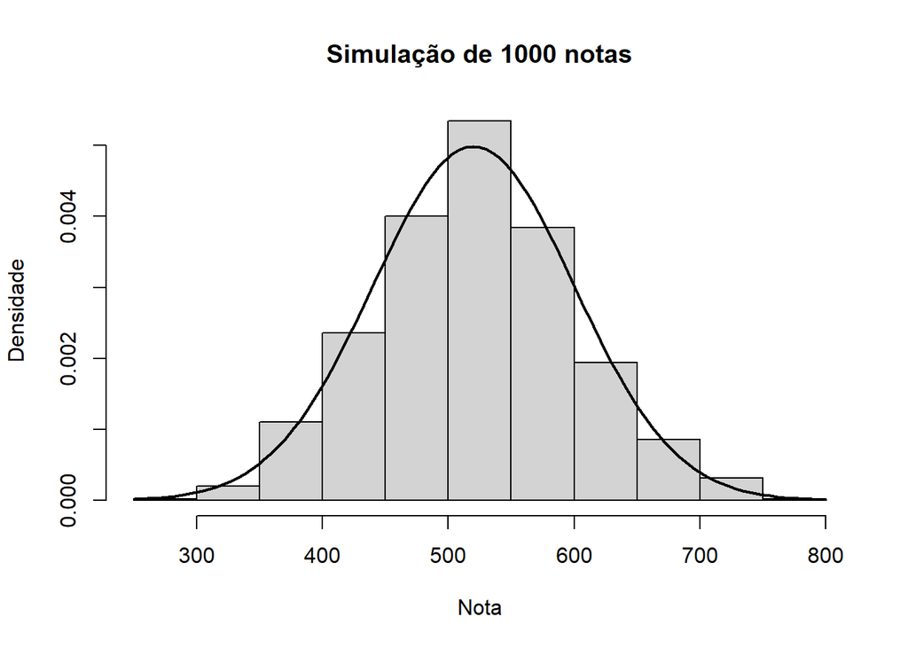

```r
set.seed(123)

x_normal <- rnorm(
  1000,
  mean = 520,
  sd = 80
)

hist(
  x_normal,
  probability = TRUE,
  main = "Simulação de 1000 notas",
  xlab = "Nota",
  ylab = "Densidade"
)

curve(
  dnorm(
    x,
    mean = 520,
    sd = 80
  ),
  add = TRUE,
  lwd = 2
)
```

O histograma permite observar a distribuição dos valores simulados e compará-la com a curva Normal teórica.

# 5 Parte 2 – Aprovação em Olimpíadas de Matemática: Distribuição Binomial

Considera-se uma turma com 20 alunos inscritos na OBMEP, sendo que historicamente 25% conseguem classificação para a segunda fase.

Assim:

$$X \sim Binomial(20,0,25)$$

A distribuição Binomial é adequada porque temos um número fixo de alunos e duas possibilidades principais para cada aluno: classificar ou não classificar.

## 5.1 Probabilidade de nenhum aluno se classificar

```r
n_bin <- 20
p_bin <- 0.25

bin_a <- dbinom(
  0,
  size = n_bin,
  prob = p_bin
)

bin_a
```

```
## [1] 0.003171212
```

O resultado é aproximadamente 0,0032.

Portanto, a probabilidade é de aproximadamente **0,32%**.

## 5.2 Probabilidade de no máximo 3 alunos se classificarem

```r
bin_b <- pbinom(
  3,
  size = n_bin,
  prob = p_bin
)

bin_b
```

```
## [1] 0.225156
```

O resultado é aproximadamente 0,2252.

Portanto, a probabilidade é de aproximadamente **22,52%**.

## 5.3 Probabilidade de 8 ou mais alunos se classificarem

```r
bin_c <- pbinom(
  7,
  size = n_bin,
  prob = p_bin,
  lower.tail = FALSE
)

bin_c
```

```
## [1] 0.1018119
```

O resultado é aproximadamente 0,1018.

Portanto, a probabilidade é de aproximadamente **10,18%**.

## 5.4 Esperança e variância

Para uma distribuição Binomial:

$$E(X)=np$$

e

$$Var(X)=np(1-p)$$

```r
esperanca_bin <- n_bin * p_bin

variancia_bin <- n_bin *
  p_bin *
  (1 - p_bin)

esperanca_bin
```

```
## [1] 5
```

```r
variancia_bin
```

```
## [1] 3.75
```

A esperança é **5 alunos** e a variância é **3,75**.

## 5.5 Simulação de 1000 turmas

```r
set.seed(123)

sim_bin <- rbinom(
  1000,
  size = 20,
  prob = 0.25
)

freq_bin <- table(sim_bin) / 1000

freq_bin
```

```
## sim_bin
##     0     1     2     3     4     5     6     7     8     9    10    11    12
## 0.003 0.023 0.062 0.136 0.200 0.192 0.174 0.116 0.052 0.030 0.010 0.001 0.001
```

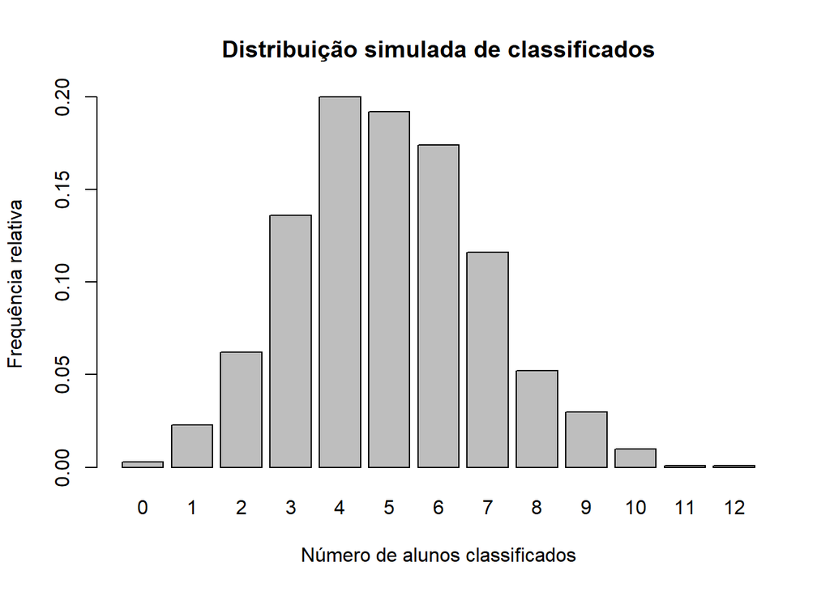

```r
barplot(
  freq_bin,
  main = "Distribuição simulada de classificados",
  xlab = "Número de alunos classificados",
  ylab = "Frequência relativa"
)
```

A simulação permite observar como as frequências relativas se aproximam das probabilidades teóricas.

# 6 Parte 3 – Evasão Escolar por Semana: Distribuição Poisson

O número de alunos que abandonam a escola por semana é modelado por uma distribuição de Poisson com média de 3 alunos por semana.

Assim:

$$X \sim Poisson(3)$$

## 6.1 Probabilidade de nenhuma evasão

```r
lambda <- 3

poi_a <- dpois(
  0,
  lambda = lambda
)

poi_a
```

```
## [1] 0.04978707
```

O resultado é aproximadamente 0,0498.

Portanto, a probabilidade é de aproximadamente **4,98%**.

## 6.2 Probabilidade de 5 ou mais evasões

```r
poi_b <- ppois(
  4,
  lambda = lambda,
  lower.tail = FALSE
)

poi_b
```

```
## [1] 0.1847368
```

O resultado é aproximadamente 0,1847.

Portanto, a probabilidade é de aproximadamente **18,47%**.

## 6.3 Probabilidade de ocorrerem entre 2 e 4 evasões

```r
poi_c <- ppois(
  4,
  lambda = lambda
) -
ppois(
  1,
  lambda = lambda
)

poi_c
```

```
## [1] 0.616115
```

O resultado é aproximadamente 0,6161.

Portanto, a probabilidade é de aproximadamente **61,61%**.

## 6.4 Probabilidade de exatamente 7 evasões em duas semanas

Se a média semanal é 3, em duas semanas a média será:

$$\lambda=6$$

```r
lambda_2 <- 6

poi_d <- dpois(
  7,
  lambda = lambda_2
)

poi_d
```

```
## [1] 0.137677
```

O resultado é aproximadamente 0,1377.

Portanto, a probabilidade é de aproximadamente **13,77%**.

## 6.5 Esperança e variância

Na distribuição de Poisson:

$$E(X)=\lambda$$

e

$$Var(X)=\lambda$$

```r
esperanca_poi <- lambda

variancia_poi <- lambda

esperanca_poi
```

```
## [1] 3
```

```r
variancia_poi
```

```
## [1] 3
```

A esperança é **3** e a variância também é **3**.

# 7 Parte 4 – Tempo de Espera no Atendimento: Distribuição Exponencial

O tempo de espera dos responsáveis na secretaria escolar segue uma distribuição Exponencial com média de 12 minutos.

Assim:

$$\lambda=\frac{1}{12}$$

## 7.1 Probabilidade de espera superior a 20 minutos

```r
media_exp <- 12

taxa_exp <- 1 / media_exp

exp_a <- pexp(
  20,
  rate = taxa_exp,
  lower.tail = FALSE
)

exp_a
```

```
## [1] 0.1888756
```

O resultado é aproximadamente 0,1889.

Portanto, a probabilidade é de aproximadamente **18,89%**.

## 7.2 Probabilidade de espera inferior a 5 minutos

```r
exp_b <- pexp(
  5,
  rate = taxa_exp
)

exp_b
```

```
## [1] 0.3407594
```

O resultado é aproximadamente 0,3408.

Portanto, a probabilidade é de aproximadamente **34,08%**.

## 7.3 Mediana do tempo de espera

```r
exp_c <- qexp(
  0.5,
  rate = taxa_exp
)

exp_c
```

```
## [1] 8.317766
```

A mediana é de aproximadamente **8,32 minutos**.

## 7.4 Propriedade da falta de memória

Se o responsável já esperou 10 minutos, deseja-se calcular a probabilidade de esperar pelo menos mais 8 minutos:

$$P(X>18|X>10)$$

Pela propriedade da falta de memória:

$$P(X>18|X>10)=P(X>8)$$

```r
exp_d <- pexp(
  18,
  rate = taxa_exp,
  lower.tail = FALSE
) /
pexp(
  10,
  rate = taxa_exp,
  lower.tail = FALSE
)

exp_d
```

```
## [1] 0.5134171
```

O resultado é aproximadamente **51,34%**.

## 7.5 Simulação de 1000 tempos de espera

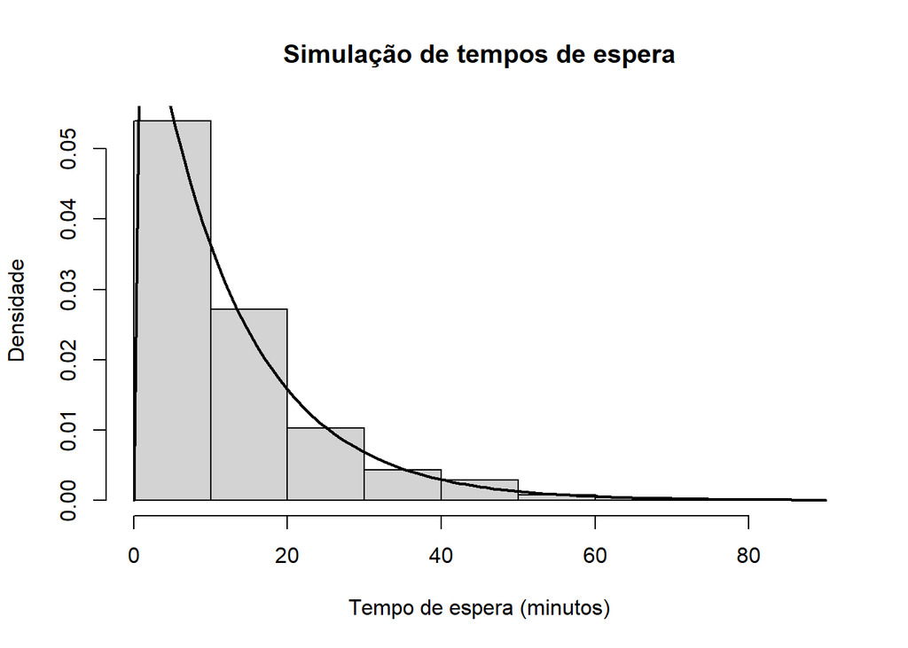

```r
set.seed(123)

x_exp <- rexp(
  1000,
  rate = 1 / 12
)

hist(
  x_exp,
  probability = TRUE,
  main = "Simulação de tempos de espera",
  xlab = "Tempo de espera (minutos)",
  ylab = "Densidade"
)

curve(
  dexp(
    x,
    rate = 1 / 12
  ),
  add = TRUE,
  lwd = 2
)
```

# 8 Parte 5 – Altura dos Alunos do 9º Ano: Distribuição Weibull

A altura dos alunos do 9º ano é modelada por uma distribuição Weibull com parâmetro de forma igual a 2 e escala igual a 160 cm.

Assim:

$$X\sim Weibull(2,160)$$
## Probabilidade de altura inferior a 140 cm

```r
forma_wei <- 2

escala_wei <- 160

wei_a <- pweibull(
  140,
  shape = forma_wei,
  scale = escala_wei
)

wei_a
```

```
## [1] 0.5349568
```

O resultado é aproximadamente 0,5350.

Portanto, a probabilidade é de aproximadamente **53,50%**.

## 8.1 Probabilidade de altura entre 150 e 175 cm

```r
wei_b <- pweibull(
  175,
  shape = forma_wei,
  scale = escala_wei
) -
pweibull(
  150,
  shape = forma_wei,
  scale = escala_wei
)

wei_b
```

```
## [1] 0.1129228
```

O resultado é aproximadamente 0,1129.

Portanto, a probabilidade é de aproximadamente **11,29%**.

## 8.2 Percentil 90

```r
wei_c <- qweibull(
  0.90,
  shape = forma_wei,
  scale = escala_wei
)

wei_c
```

```
## [1] 242.7883
```

O resultado é aproximadamente **242,79 cm**.

## 8.3 Média e desvio padrão

A média da distribuição Weibull é:

$$E(X)=\lambda\Gamma\left(1+\frac{1}{k}\right)$$

```r
media_wei <- escala_wei *
  gamma(
    1 + 1 / forma_wei
  )

variancia_wei <- escala_wei^2 *
  (
    gamma(
      1 + 2 / forma_wei
    ) -
    gamma(
      1 + 1 / forma_wei
    )^2
  )

desvio_wei <- sqrt(
  variancia_wei
)

media_wei
```

```
## [1] 141.7963
```

```r
desvio_wei
```

```
## [1] 74.12022
```

A média é aproximadamente **141,80 cm** e o desvio padrão aproximadamente **74,12 cm**.

## 8.4 Função de risco

A função de risco da distribuição Weibull é:

$$h(x)=\frac{k}{\lambda}
\left(\frac{x}{\lambda}\right)^{k-1}$$

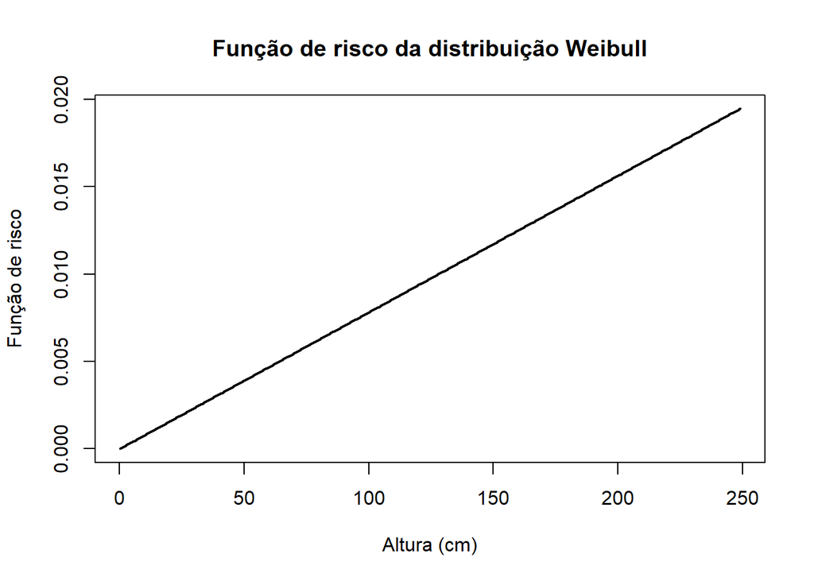

```r
x_seq <- seq(
  0.1,
  250,
  by = 1
)

hazard <- (
  2 / 160
) *
(
  x_seq / 160
)^(2 - 1)

plot(
  x_seq,
  hazard,
  type = "l",
  lwd = 2,
  main = "Função de risco da distribuição Weibull",
  xlab = "Altura (cm)",
  ylab = "Função de risco"
)
```

# 9 Parte 6 – Precipitação Mensal: Distribuição Gama

A precipitação mensal é modelada por uma distribuição Gama com parâmetro de forma igual a 4 e taxa igual a 0,02.

Assim:

$$X\sim Gama(4,0,02)$$

## 9.1 Probabilidade de chuva superior a 300 mm

```r
forma_gama <- 4

taxa_gama <- 0.02

gam_a <- pgamma(
  300,
  shape = forma_gama,
  rate = taxa_gama,
  lower.tail = FALSE
)

gam_a
```

```
## [1] 0.1512039
```

O resultado é aproximadamente 0,1512.

Portanto, a probabilidade é de aproximadamente **15,12%**.

## 9.2 Probabilidade de chuva entre 150 e 250 mm

```r
gam_b <- pgamma(
  250,
  shape = forma_gama,
  rate = taxa_gama
) -
pgamma(
  150,
  shape = forma_gama,
  rate = taxa_gama
)

gam_b
```

```
## [1] 0.382206
```

O resultado é aproximadamente 0,3822.

Portanto, a probabilidade é de aproximadamente **38,22%**.

## 9.3 Percentil 95

```r
gam_c <- qgamma(
  0.95,
  shape = forma_gama,
  rate = taxa_gama
)

gam_c
```

```
## [1] 387.6828
```

O resultado é aproximadamente **387,68 mm**.

## 9.4 Esperança e variância

Para uma distribuição Gama:

$$E(X)=\frac{\alpha}{\beta}$$

e

$$Var(X)=\frac{\alpha}{\beta^2}$$

```r
esperanca_gam <- forma_gama /
  taxa_gama

variancia_gam <- forma_gama /
  taxa_gama^2

esperanca_gam
```

```
## [1] 200
```

```r
variancia_gam
```

```
## [1] 10000
```

A esperança é **200 mm** e a variância é **10.000 mm²**.

## 9.5 Simulação de 120 meses

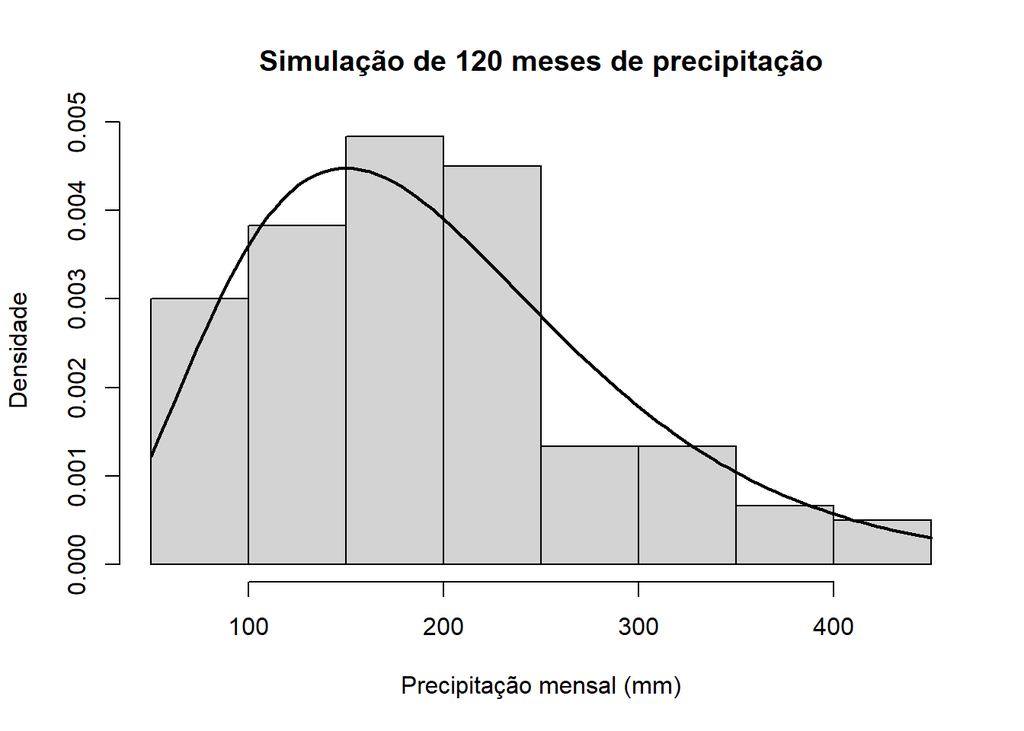

```r
set.seed(123)

x_gama <- rgamma(
  120,
  shape = 4,
  rate = 0.02
)

hist(
  x_gama,
  probability = TRUE,
  main = "Simulação de 120 meses de precipitação",
  xlab = "Precipitação mensal (mm)",
  ylab = "Densidade"
)

curve(
  dgamma(
    x,
    shape = 4,
    rate = 0.02
  ),
  add = TRUE,
  lwd = 2
)
```

# 10 Parte 7 – Análise Integrada com Simulação de Monte Carlo

A simulação de Monte Carlo permite utilizar números aleatórios para aproximar probabilidades e outros resultados estatísticos.

Nesta etapa foram realizadas 10.000 simulações das notas do ENEM.

```r
set.seed(123)

n_sim <- 10000

x_mc <- rnorm(
  n_sim,
  mean = 520,
  sd = 80
)

proporcao_simulada <- mean(
  x_mc < 400
)

proporcao_teorica <- pnorm(
  400,
  mean = 520,
  sd = 80
)

proporcao_simulada
```

```
## [1] 0.067
```

```r
proporcao_teorica
```

```
## [1] 0.0668072
```

Os dois valores tendem a ser próximos. A pequena diferença ocorre porque a simulação utiliza uma quantidade finita de observações aleatórias.

```r
comparacao_mc <- data.frame(
  Metodo = c(
    "Teórico",
    "Monte Carlo"
  ),
  Probabilidade = c(
    proporcao_teorica,
    proporcao_simulada
  )
)

comparacao_mc
```

```
##        Metodo Probabilidade
## 1     Teórico     0.0668072
## 2 Monte Carlo     0.0670000
```

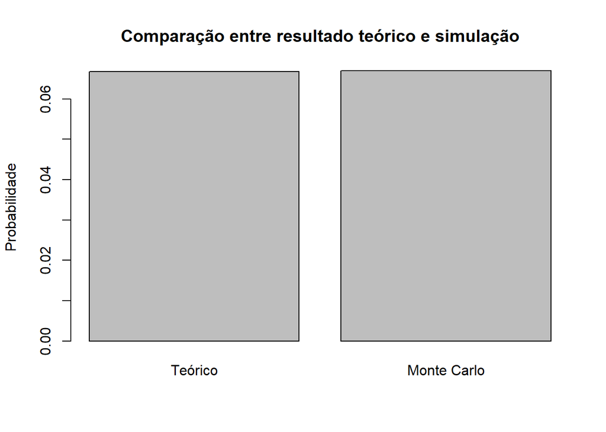

```r
barplot(
  comparacao_mc$Probabilidade,
  names.arg = comparacao_mc$Metodo,
  main = "Comparação entre resultado teórico e simulação",
  ylab = "Probabilidade"
)
```

## 10.1 Importância pedagógica

A simulação permite que os estudantes observem, na prática, o comportamento de um modelo probabilístico.

Em vez de trabalhar somente com fórmulas, o professor pode propor situações nas quais os alunos realizem experimentos virtuais e comparem as frequências observadas com as probabilidades calculadas teoricamente.

Essa abordagem favorece a compreensão de conceitos como aleatoriedade, frequência relativa, probabilidade, média e distribuição dos dados.

# 11 Resultados e Discussão

Os resultados obtidos mostram que diferentes fenômenos podem ser representados por diferentes modelos probabilísticos.

Na distribuição Normal, foi possível analisar as notas do ENEM, calculando probabilidades, percentis e a probabilidade associada à média amostral.

Na distribuição Binomial, a situação da classificação para a OBMEP permitiu trabalhar com número fixo de tentativas e dois possíveis resultados.

A distribuição de Poisson foi utilizada para representar uma contagem de eventos em determinado intervalo de tempo.

A distribuição Exponencial foi utilizada para representar tempos de espera, permitindo também explorar a propriedade da falta de memória.

Na distribuição Weibull, além das probabilidades e medidas descritivas, foi possível trabalhar com a função de risco.

A distribuição Gama foi aplicada à precipitação mensal, permitindo calcular probabilidades, percentis e realizar uma simulação.

Do ponto de vista pedagógico, essas situações mostram que a Estatística pode ser ensinada a partir de problemas contextualizados. O estudante pode compreender que as distribuições de probabilidade não são apenas fórmulas isoladas, mas modelos utilizados para representar fenômenos.

O uso do R amplia essas possibilidades porque permite realizar cálculos rapidamente, produzir gráficos, simular situações e comparar resultados teóricos e experimentais.

# 12 Possibilidades de Aplicação na Educação Básica

As situações estudadas podem ser transformadas em atividades investigativas para os estudantes.

A distribuição Normal pode ser trabalhada a partir das notas de avaliações, discutindo média, dispersão e percentis.

A distribuição Binomial pode ser apresentada por meio de situações envolvendo participação em olimpíadas, acertos em questões ou experimentos com resultados de sucesso e fracasso.

A distribuição de Poisson pode ser relacionada a contagens, como número de ocorrências de determinado evento em uma semana.

A distribuição Exponencial pode ser explorada por meio de tempos de espera, atendimento ou intervalo entre acontecimentos.

As distribuições Weibull e Gama podem ser utilizadas principalmente em atividades de modelagem e projetos interdisciplinares.

Nesse sentido, o computador não substitui o raciocínio matemático. Ele funciona como uma ferramenta que permite experimentar, visualizar, testar hipóteses e interpretar resultados.

# 13 Conclusão

O desenvolvimento deste relatório permitiu analisar diferentes distribuições de probabilidade a partir de situações relacionadas ao contexto escolar e social.

Foram estudadas as distribuições Normal, Binomial, Poisson, Exponencial, Weibull e Gama, utilizando cálculos teóricos e simulações realizadas na linguagem R.

Os resultados mostram que a escolha adequada de uma distribuição depende das características do fenômeno analisado.

A utilização de simulações mostrou-se especialmente importante porque possibilita comparar aquilo que é previsto matematicamente com aquilo que ocorre em experimentos aleatórios.

No contexto da Educação Básica, o trabalho com situações reais e ferramentas computacionais pode tornar o ensino de Estatística mais investigativo e próximo da realidade dos estudantes.

# 14 Síntese dos Principais Resultados

```r
resultados <- data.frame(
  Distribuicao = c(
    "Normal",
    "Binomial",
    "Poisson",
    "Exponencial",
    "Weibull",
    "Gama"
  ),
  Situacao = c(
    "Notas do ENEM",
    "Classificação na OBMEP",
    "Evasão escolar",
    "Tempo de espera",
    "Altura dos alunos",
    "Precipitação"
  ),
  Parametros = c(
    "μ = 520; σ = 80",
    "n = 20; p = 0,25",
    "λ = 3",
    "média = 12",
    "forma = 2; escala = 160",
    "forma = 4; taxa = 0,02"
  )
)

resultados
```

```
##   Distribuicao               Situacao              Parametros
## 1       Normal          Notas do ENEM         μ = 520; σ = 80
## 2     Binomial Classificação na OBMEP        n = 20; p = 0,25
## 3      Poisson         Evasão escolar                   λ = 3
## 4  Exponencial        Tempo de espera              média = 12
## 5      Weibull      Altura dos alunos forma = 2; escala = 160
## 6         Gama           Precipitação  forma = 4; taxa = 0,02
```

# 15 Referências

BUSSAB, W. O.; MORETTIN, P. A. *Estatística Básica*. Saraiva.

MONTGOMERY, D. C.; RUNGER, G. C. *Estatística Aplicada e Probabilidade para Engenheiros*. LTC.

R CORE TEAM. *R: A Language and Environment for Statistical Computing*. Vienna: R Foundation for Statistical Computing. https://bendeivide.github.io/courses/profmat-probest/normal2026.2/

https://bendeivide.github.io/books/epaec/

MEYER, Paul L. Probabilidade: Aplicações à Estatística. 2. ed. Rio de Janeiro: LTC, 1983.

BRASIL. Ministério da Educação. Base Nacional Comum Curricular. Brasília: MEC, 2018.

https://bendeivide.github.io/books/epaec/

# 16 Considerações Finais

A realização desta atividade possibilitou integrar conhecimentos de Probabilidade, Estatística, programação e Educação Matemática.

A utilização do R permitiu não somente realizar os cálculos solicitados, mas também visualizar os modelos, gerar dados simulados e verificar experimentalmente resultados obtidos pela teoria.

Dessa forma, a atividade relaciona o conhecimento matemático com situações contextualizadas e apresenta possibilidades de utilização dos recursos computacionais como apoio ao ensino de Estatística na Educação Básica.